# Презентация по лабораторной работе №5

Основы информационной безопасности

Мажитов М. А.

Российский университет дружбы народов, Москва, Россия

28 сентября 2024

## Докладчик

- Мажитов Магомед Асхабович
- студент группы НКНбд-01-21
- Российский университет дружбы народов

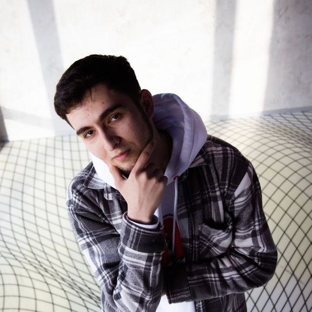

## Цель

Изучение механизмов изменения идентификаторов, применения SetUID- и Sticky-битов. Получение практических навыков работы в консоли с дополнительными атрибутами. Рассмотрение работы механизма смены идентификатора процессов пользователей, а также влияние бита Sticky на запись и удаление файлов.

## Выполнение лабораторной работы.

Проверил установлен ли компилятор *gcc* и *g++*.

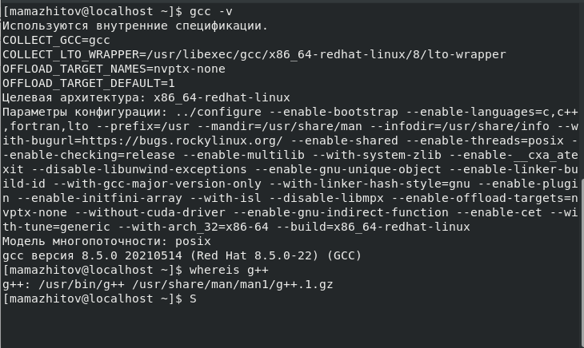

Компилятор

Вошел в систему от имени пользователя guest и создал программу simpleid.c.

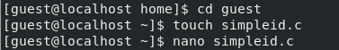

Создание simpleid.c

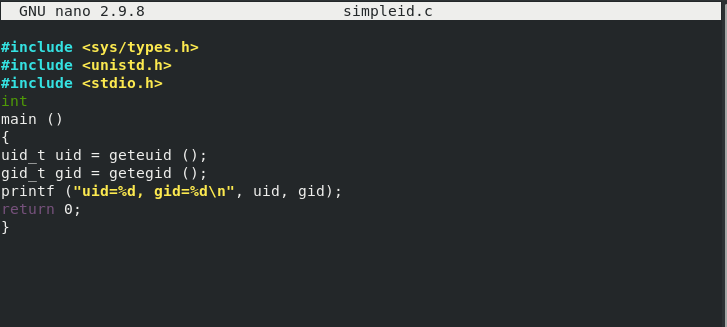

Код программы simpleid.c

Скомплилировал программу и убедился, что файл программы создан. Далее запустил исполнительный файл, а также ввел системную программу *id* для дальнейшего сравнения выводов.

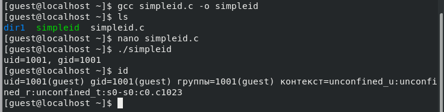

Компиляция simpleid.c

Результаты идентичны.

Создал программу *simpleid2.c*.

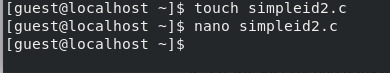

Создание simpleid2.c

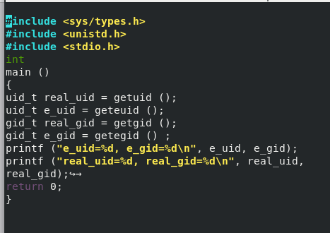

Код программы simpleid2.c

Скомпилоровал программу и сравнил выводы прошлой и новой программ.

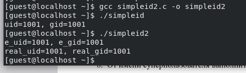

Сравнение

Далее я поменял владельца файла *simpleid2* и изменил права доступа к нему.

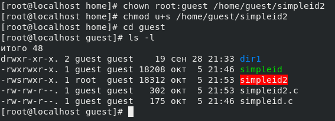

Манипуляции simpleid2

Запустил *simpleid2* и *id*.

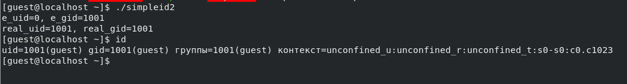

Сравнение

Как мы видим после изменения владельца *simpleid2*, вывод программы изменился.

Создал программу *readfile.c*. Скомпилировал файл и далее также изменил владельца *readfile* и права доступа к нему, так, чтобы только суперпользователь(root) мог прочитать его, a guest не мог.

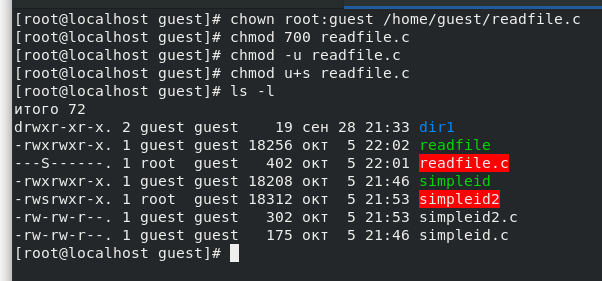

Изменение владельца readfile

Попробовал прочитать файл от имени *guest*.

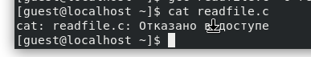

Попытка прочитать readfile

Попытка не увенчалась успехом.

Проверил, может ли программа readfile прочитать файл *readfile.c* и */etc/shadow*.

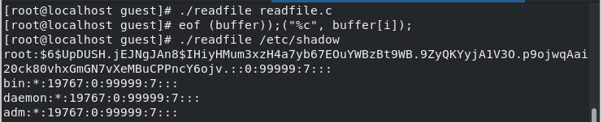

Попытка запустить readfile

Проверил, установлен ли атрибут *Sticky* на директории /tmp.

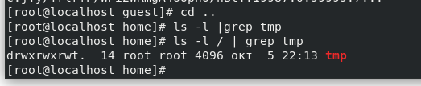

Проверка наличия Sticky атрибута

От имени пользователя *guest* создал файл *file01.txt* в директории */tmp* со словом test и изменил права доступа к нему.

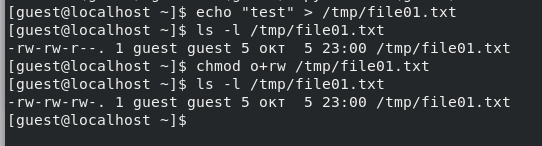

Создание file01.txt

От пользователя guest2 (не являющегося владельцем) попробовал прочитать файл, переписать содержимое файла, а также дописать в файл новые данные.

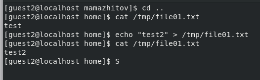

Манипуляции с file01.txt

Попробовал удалить файл.

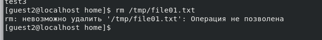

Попытка удалить file01.txt

Повысив права до суперпользователя, снял атрибут *t*.

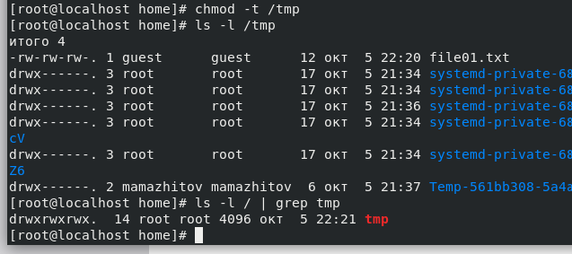

Снятие атрибута t

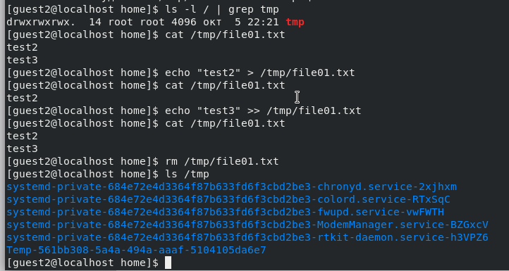

Манипуляции с file01.txt

В этот раз получилось удалить *file01.txt*.

[figure not shown]

Попытка удалить file01.txt

## Вывод

Изучил механизм изменения идентификаторов, применил SetUID- и Sticky-биты. Получил практические навыки работы в консоли с дополнительными атрибутами. Рассмотрел работы механизма смены идентификатора процессов пользователей, а также влияние бита Sticky на запись и удаление файлов.

## Список литературы. Библиография